# Applicazione delle reti neurali artificiali su dati trascrittomici

**Dott. Fonzino Adriano**

**Ricercatore presso il lab. di Bioinformatica del Dipartimento di Bioscienze, Biotecnologie e Ambiente - Università degli Studi di Bari "Aldo Moro"**

**21/02/2024 - BARI**

Grazie all'avvento delle **tecnologie di sequenziamento massivo degli acidi nucleici di nuova generazione** è diventato possibile avere abbastanza agevolmente un'immagine dell'intero **profilo di espressione genica** di un dato tessuto/campione in una determinata condizione. Come è noto, l'**espressione genica** è il processo attraverso cui l'**informazione** contenuta in un **gene** (**DNA**) viene convertita di solito una **proteina** (effettore molecolare) attraverso la produzione di un intermedio a **RNA** (**trascritto**). Il livello di espressione delle migliaia di trascritti prodotti in un tessuto o in una cellula che nel loro insieme vengono identificati con il termine **trascrittoma**, può essere identificato e quantificato finemente con varie tecnologie, dalle più classiche come ad esempio esperimenti di **microarray**, fino alle più moderne tecniche di **RNA-seq** di seconda e terza generazione.

[figure not shown]

In questa **dimostrazione pratica** lavoreremo su uno storico dataset costruito da Singh et al. tramite l'analisi dei **livelli di espressione genica** di **6033 geni** a partire da campioni di prostata provenienti da **tessuto sano** e/o **malato** (tessuti prelevati dalla ghiandola prostatica con diagnosi tumorale). Il **cancro alla prostata** è infatti una famiglia di tumori della ghiandola prostatica molto eterogenea sia a livello istologico che clinico e rappresenta una neoplasia tipica dell'età avanzata. In generale, per ognuno di questi campioni in esame, avremo a disposizione i **livelli degli RNA trascritti dai geni espressi** ed utilizzeremo questa grossa mole di informazioni per selezionare quellii più **significativi** in grado cioè di **discriminare** tra **sano** e **cancro**. Successivamente, a partire da questa **lista di RNA trascritti significativi** selezionati con un semplice test statistico comparativo, addestreremo un esempio di **percettronene multistrato** (modello di rete neurale artificiale) in grado di funzionare efficacemente come un **classificatore** per distinguere un **campione sano** da uno **malato** a partire dal solo profilo trascrittomico.

Ma che cosa è un **percettrone** e cosa è una **rete neurale artificiale**? Il **percettrone** è il primo modello di **neurone artificiale** e fu introdotto nel 1958 dallo psicologo **Frank Rosenblatt**. La più semplice **rete neurale artificiale** è infatti un insieme di singole unità simili al percettrone poste su più **strati** e connesse tra loro come un **grafo** diretto. E' denominato per questo motivo come **Multi Layer Perceptron** (MLP), che altro non è che una modifica del Percettrone lineare standard e che, a differenza di quest'ultimo, può distinguere i dati che non sono **separabili linearmente** (dati più complessi come quelli trascrittomici).

[figure not shown]

**Ma come mettere in pratica tutto ciò?** Ci sono numerosi **linguaggi di programmazione** che supportano **librerie** per il la **costruzione** ed il **training** di modelli di **deep learning** di questo tipo. Uno dei più diffusi è sicuramente il linugaggio di programmazione **Python**, che con le sue librerie permette di maneggiare grosse moli di dati e di preprocessarli al fine di addestrare anche modelli di **reti neurali artificiali**.

### Caricamento del dato e selezione trascritti più significativi

```python
# importiamo le librerie Python necessarie per i primi processamenti
# il simbolo '#' è una linea (o parte di essa) di commento che non viene eseguita dal programma
import os
from glob import glob
import pandas as pd # --> manimpolazione dataframes e tabelle
import numpy as np # --> manipolazione di matrici e vettori
import matplotlib.pyplot as plt # --> per la visualizzazione e produzione di grafici
import seaborn as sn # --> produzione grafici a partire da dataframes pandas o numpy
# libreria scikit-learn (sklearn abbr.) per il machine learning in python
from sklearn.decomposition import PCA # --> riduzione della dimensionalità con Analisi delle Componenti Principali (PCA)
from sklearn.preprocessing import StandardScaler # --> libreria per standardizzare i dati
# libreria scipy per il calcolo scientifico in python:
from scipy.stats import ttest_ind # --> ttest_ind è una funziona per effettuare un semplice test statistico tra due campioni
from tqdm import tqdm # --> implementazione metodi per progress bar in cicli for
```

```python
# carichiamo il dataset in memoria come DataFrame usando la libreria Pandas
df = pd.read_table("Prostata.txt", index_col=0, sep=" ")
df
```

| Status | G1 | G2 | G3 | G4 | G5 | G6 | G7 | G8 | G9 | G10 | ... | G6024 | G6025 | G6026 | G6027 | G6028 | G6029 | G6030 | G6031 | G6032 | G6033 |
| --- | --- | --- | --- | --- | --- | --- | --- | --- | --- | --- | --- | --- | --- | --- | --- | --- | --- | --- | --- | --- | --- |
| control | -0.930895 | -0.839996 | 0.062508 | -0.361594 | -1.124427 | -1.180492 | -1.092276 | -1.149624 | -1.157503 | 0.219849 | ... | 0.459535 | 0.492456 | -0.753197 | 0.377710 | -0.845797 | 0.686091 | -1.091779 | 0.347228 | -0.901310 | -0.252259 |
| control | -0.751885 | -0.848271 | 0.102895 | 2.421034 | 0.182211 | 0.639267 | -0.224728 | 0.119039 | 1.694874 | -0.074817 | ... | 2.485080 | -0.959873 | 1.374652 | -0.903991 | 1.332845 | -0.574808 | 2.143548 | 0.101821 | 1.326812 | -0.091503 |
| control | -0.545781 | -0.851687 | -0.003043 | -0.122089 | 0.837907 | -1.195882 | -0.931749 | -1.164679 | -0.549045 | 3.828663 | ... | 0.765470 | -0.869585 | -0.362556 | -0.907472 | -0.341481 | -0.577905 | -0.006464 | -0.920312 | -0.085084 | -0.704808 |
| control | -1.078519 | -0.159610 | 0.215347 | -0.096277 | 1.050548 | 0.654914 | 1.086128 | -1.127224 | 0.603476 | -0.532284 | ... | -1.159263 | -0.928211 | -0.909437 | -0.872889 | -0.823525 | -1.055268 | -1.069403 | -0.792237 | -0.879015 | -0.672488 |
| control | -0.994677 | -0.751905 | -1.163109 | -1.130144 | 1.695673 | 0.878677 | -1.097698 | 1.490272 | 1.314783 | -1.112842 | ... | -1.187877 | 0.407184 | -0.935771 | -0.898889 | -0.849075 | -1.082933 | -1.097196 | -0.911702 | -0.905071 | -0.696659 |
| ... | ... | ... | ... | ... | ... | ... | ... | ... | ... | ... | ... | ... | ... | ... | ... | ... | ... | ... | ... | ... | ... |
| cancer | 2.054122 | -0.450853 | -1.049600 | 0.553022 | 3.995967 | -1.105746 | -1.164153 | 0.138336 | -0.282382 | -0.938565 | ... | 1.691171 | -0.892589 | 1.461973 | -0.163629 | 2.157779 | -0.841948 | 1.419036 | 0.090991 | 0.898067 | -0.546613 |
| cancer | 2.799498 | 1.385720 | 1.186599 | 0.118476 | 0.115477 | 0.378246 | -0.102450 | -1.149203 | -0.659127 | -0.920858 | ... | 0.089144 | -0.875918 | -0.495349 | -0.490171 | -0.508972 | 0.488729 | -0.006916 | -0.795695 | -0.086979 | -0.859999 |
| cancer | 1.294162 | -1.143997 | 0.962634 | 1.220066 | -1.167392 | -0.135083 | -0.159211 | -1.144376 | -1.094105 | -0.914736 | ... | -0.937162 | -0.869541 | -0.881752 | -0.877622 | -1.064419 | -1.167889 | -0.894468 | -0.788863 | -0.681033 | -0.853532 |
| cancer | 2.905588 | -0.282119 | -0.026753 | -1.138651 | -1.195660 | -0.389769 | 0.952723 | -0.887806 | -1.030068 | 0.862200 | ... | -0.961822 | -0.309148 | -0.905544 | -0.567570 | -1.091074 | 0.351666 | -0.918460 | -0.811200 | -0.701681 | -0.876882 |
| cancer | 3.434504 | -1.174233 | 1.533532 | 0.174831 | -0.203642 | 1.316810 | -1.166670 | 0.579443 | 0.708166 | 0.337700 | ... | -0.965886 | 0.151368 | -0.910070 | -0.574877 | -1.094074 | -1.198300 | -0.342060 | -0.243875 | -0.707884 | -0.161796 |

102 rows × 6033 columns

```python
# usiamo l'indice come variabile di risposta
df["status"] = df.index
df.reset_index(inplace=True, drop=True)
df
```

|  | G1 | G2 | G3 | G4 | G5 | G6 | G7 | G8 | G9 | G10 | ... | G6025 | G6026 | G6027 | G6028 | G6029 | G6030 | G6031 | G6032 | G6033 | status |
| --- | --- | --- | --- | --- | --- | --- | --- | --- | --- | --- | --- | --- | --- | --- | --- | --- | --- | --- | --- | --- | --- |
| 0 | -0.930895 | -0.839996 | 0.062508 | -0.361594 | -1.124427 | -1.180492 | -1.092276 | -1.149624 | -1.157503 | 0.219849 | ... | 0.492456 | -0.753197 | 0.377710 | -0.845797 | 0.686091 | -1.091779 | 0.347228 | -0.901310 | -0.252259 | control |
| 1 | -0.751885 | -0.848271 | 0.102895 | 2.421034 | 0.182211 | 0.639267 | -0.224728 | 0.119039 | 1.694874 | -0.074817 | ... | -0.959873 | 1.374652 | -0.903991 | 1.332845 | -0.574808 | 2.143548 | 0.101821 | 1.326812 | -0.091503 | control |
| 2 | -0.545781 | -0.851687 | -0.003043 | -0.122089 | 0.837907 | -1.195882 | -0.931749 | -1.164679 | -0.549045 | 3.828663 | ... | -0.869585 | -0.362556 | -0.907472 | -0.341481 | -0.577905 | -0.006464 | -0.920312 | -0.085084 | -0.704808 | control |
| 3 | -1.078519 | -0.159610 | 0.215347 | -0.096277 | 1.050548 | 0.654914 | 1.086128 | -1.127224 | 0.603476 | -0.532284 | ... | -0.928211 | -0.909437 | -0.872889 | -0.823525 | -1.055268 | -1.069403 | -0.792237 | -0.879015 | -0.672488 | control |
| 4 | -0.994677 | -0.751905 | -1.163109 | -1.130144 | 1.695673 | 0.878677 | -1.097698 | 1.490272 | 1.314783 | -1.112842 | ... | 0.407184 | -0.935771 | -0.898889 | -0.849075 | -1.082933 | -1.097196 | -0.911702 | -0.905071 | -0.696659 | control |
| ... | ... | ... | ... | ... | ... | ... | ... | ... | ... | ... | ... | ... | ... | ... | ... | ... | ... | ... | ... | ... | ... |
| 97 | 2.054122 | -0.450853 | -1.049600 | 0.553022 | 3.995967 | -1.105746 | -1.164153 | 0.138336 | -0.282382 | -0.938565 | ... | -0.892589 | 1.461973 | -0.163629 | 2.157779 | -0.841948 | 1.419036 | 0.090991 | 0.898067 | -0.546613 | cancer |
| 98 | 2.799498 | 1.385720 | 1.186599 | 0.118476 | 0.115477 | 0.378246 | -0.102450 | -1.149203 | -0.659127 | -0.920858 | ... | -0.875918 | -0.495349 | -0.490171 | -0.508972 | 0.488729 | -0.006916 | -0.795695 | -0.086979 | -0.859999 | cancer |
| 99 | 1.294162 | -1.143997 | 0.962634 | 1.220066 | -1.167392 | -0.135083 | -0.159211 | -1.144376 | -1.094105 | -0.914736 | ... | -0.869541 | -0.881752 | -0.877622 | -1.064419 | -1.167889 | -0.894468 | -0.788863 | -0.681033 | -0.853532 | cancer |
| 100 | 2.905588 | -0.282119 | -0.026753 | -1.138651 | -1.195660 | -0.389769 | 0.952723 | -0.887806 | -1.030068 | 0.862200 | ... | -0.309148 | -0.905544 | -0.567570 | -1.091074 | 0.351666 | -0.918460 | -0.811200 | -0.701681 | -0.876882 | cancer |
| 101 | 3.434504 | -1.174233 | 1.533532 | 0.174831 | -0.203642 | 1.316810 | -1.166670 | 0.579443 | 0.708166 | 0.337700 | ... | 0.151368 | -0.910070 | -0.574877 | -1.094074 | -1.198300 | -0.342060 | -0.243875 | -0.707884 | -0.161796 | cancer |

102 rows × 6034 columns

```python
# vediamo quanti campioni abbiamo e come sono distribuiti tra sani e malati
df.status.value_counts()
```

```
cancer     52
control    50
Name: status, dtype: int64
```

```python
# con Pandas possiamo accedere alle celle/righe o colonne che desideriamo nel dataframe
# ad es. selezioniamo il 3° campione e vediamo le ultime 5 colonne
df.iloc[2,-5:]
```

```
G6030    -0.006464
G6031    -0.920312
G6032    -0.085084
G6033    -0.704808
status     control
Name: 2, dtype: object
```

```python
######### SKIPPED THIS FOR TIME CONSTRAIN #########
######### SKIPPED THIS FOR TIME CONSTRAIN #########
######### SKIPPED THIS FOR TIME CONSTRAIN #########

# effettuiamo un t-test per ogni gene paragonando sano e malato vedendo quali sono i geni
# la cui espressione è alterata dal tumore
p_values = []
genes = []
with tqdm(total=df.shape[1]-1) as pbar:
    for g in df.columns[:-1]:
        stat, p = ttest_ind(df.query("status == 'control'")[g], df.query("status == 'cancer'")[g])
        p_values.append(p)
        genes.append(g)
        pbar.update(1)

p_values = pd.DataFrame(p_values)
p_values.index = genes
p_values.columns = ["p-value"]

# salviamo sul disco per risparmiare tempo
p_values.to_csv("p_values.tsv", sep="\t")

# visualizziamo i p-values
p_values
```

|  | p-value |
| --- | --- |
| G1 | 0.141687 |
| G2 | 0.000382 |
| G3 | 0.977928 |
| G4 | 0.254697 |
| G5 | 0.888118 |
| ... | ... |
| G6029 | 0.773899 |
| G6030 | 0.434631 |
| G6031 | 0.234786 |
| G6032 | 0.917597 |
| G6033 | 0.361764 |

6033 rows × 1 columns

```python
# ricarichiamo i pvalues calcolati nella cella di codice precedente e salvati sul disco
# in un pandas DataFrame
p_values = pd.read_table("p_values.tsv", index_col=0)

# correggiamo per tenere sotto controllo i falsi positivi usando la procedura di
# Benjamini & Hochberg (1995) per test multipli
# carichiamo la libreria necessaria
from statsmodels.stats.multitest import multipletests
# procedura di correzione dei p-values
p_values["p-value-adj"] = multipletests(p_values["p-value"].values, method="fdr_bh")[1]
# visualizziamo il dataframe
p_values
```

|  | p-value | p-value-adj |
| --- | --- | --- |
| G1 | 0.141687 | 0.786718 |
| G2 | 0.000382 | 0.061260 |
| G3 | 0.977928 | 0.995834 |
| G4 | 0.254697 | 0.865197 |
| G5 | 0.888118 | 0.982059 |
| ... | ... | ... |
| G6029 | 0.773899 | 0.969060 |
| G6030 | 0.434631 | 0.918302 |
| G6031 | 0.234786 | 0.859505 |
| G6032 | 0.917597 | 0.982059 |
| G6033 | 0.361764 | 0.905143 |

6033 rows × 2 columns

```python
# vediamo il mumero di geni significativi dopo correzione
print("Geni con p <= 0.1:", p_values[p_values["p-value-adj"]<= 0.1].shape)
```

```
Geni con p <= 0.1: (59, 2)
```

```python
# selezioniamo solo questi geni più significativi
p_values[p_values["p-value-adj"]<= 0.1].index
```

```
Index(['G2', 'G11', 'G332', 'G364', 'G579', 'G610', 'G694', 'G698', 'G702',
       'G721', 'G735', 'G739', 'G805', 'G905', 'G914', 'G921', 'G1068',
       'G1077', 'G1089', 'G1113', 'G1130', 'G1314', 'G1346', 'G1557', 'G1588',
       'G1589', 'G1720', 'G2370', 'G2856', 'G2897', 'G2945', 'G3017', 'G3260',
       'G3269', 'G3282', 'G3292', 'G3375', 'G3505', 'G3600', 'G3647', 'G3665',
       'G3930', 'G3940', 'G3991', 'G4000', 'G4040', 'G4073', 'G4088', 'G4104',
       'G4154', 'G4316', 'G4331', 'G4396', 'G4492', 'G4518', 'G4546', 'G4549',
       'G4552', 'G4981'],
      dtype='object')
```

```python
# Selezioniamo solo i geni significativamente alterati nel tumore rispetto al controllo
# e carichiamoli in un nuovo dataframe 'df_sel'
df_sel = df[p_values[p_values["p-value-adj"]<= 0.1].index].copy()
df_sel["status"] = df["status"]
df_sel
```

|  | G2 | G11 | G332 | G364 | G579 | G610 | G694 | G698 | G702 | G721 | ... | G4316 | G4331 | G4396 | G4492 | G4518 | G4546 | G4549 | G4552 | G4981 | status |
| --- | --- | --- | --- | --- | --- | --- | --- | --- | --- | --- | --- | --- | --- | --- | --- | --- | --- | --- | --- | --- | --- |
| 0 | -0.839996 | 0.393209 | -0.839996 | 1.372060 | -0.839996 | -0.930963 | -0.958053 | -0.583812 | -0.597160 | -0.842756 | ... | -0.181600 | -0.192898 | -0.230322 | 0.389474 | -0.845797 | -0.629377 | -0.722250 | 0.899467 | -0.766643 | control |
| 1 | -0.848271 | -0.937257 | -0.525572 | -0.054194 | -0.848271 | 0.256079 | -0.017063 | 2.068874 | 0.983103 | -0.851058 | ... | 0.714279 | 0.233154 | 1.133988 | 1.077126 | -0.854128 | -0.430177 | -0.729384 | -0.874989 | -1.169673 | control |
| 2 | -0.851687 | -0.940777 | -0.851687 | -1.320633 | 3.013396 | -0.943642 | 3.418485 | -0.846355 | 0.612707 | -0.854477 | ... | 0.548854 | 0.314244 | 2.179618 | 0.796824 | -0.857551 | -0.718064 | -0.732661 | 0.386080 | -1.173464 | control |
| 3 | -0.159610 | -0.282926 | -0.817727 | 1.556194 | -0.817727 | -0.102669 | 0.209619 | -0.016247 | 1.803078 | -0.820486 | ... | 0.398471 | -0.938447 | 0.052256 | 0.570658 | -0.823525 | -0.864175 | -0.700031 | 1.289755 | -1.135910 | control |
| 4 | -0.751905 | -0.838783 | 0.209386 | 0.070094 | 0.329308 | -0.934982 | -0.962308 | 3.395272 | -0.221297 | -0.846008 | ... | 1.021204 | -0.965045 | 1.313799 | 0.769754 | 0.078228 | 0.195784 | -0.473754 | 0.566918 | -1.164311 | control |
| ... | ... | ... | ... | ... | ... | ... | ... | ... | ... | ... | ... | ... | ... | ... | ... | ... | ... | ... | ... | ... | ... |
| 97 | -0.450853 | 1.262782 | -1.171791 | -0.905010 | -1.171791 | 0.976777 | -0.887323 | -0.563404 | -0.842824 | -0.865467 | ... | 0.255232 | 0.242431 | -1.171791 | -0.145663 | 0.629262 | 0.333048 | 1.465574 | 0.024254 | 0.943742 | cancer |
| 98 | 1.385720 | 0.409620 | -1.148826 | -0.888060 | -1.148825 | 0.508528 | -0.780140 | -0.804159 | -0.827275 | -0.849408 | ... | -0.248025 | 2.559647 | 0.293480 | 0.460800 | -1.012331 | 0.755073 | -0.049153 | -0.812931 | 0.515681 | cancer |
| 99 | -1.143997 | 0.070594 | -1.143997 | 0.188338 | -0.209241 | 1.918181 | 0.386794 | -0.797375 | -0.820622 | -0.750191 | ... | 0.744216 | -1.145189 | -1.143997 | -0.947413 | 0.725631 | -0.543637 | -0.500475 | -0.806197 | 0.467788 | cancer |
| 100 | -0.282119 | 0.660468 | -0.282119 | -0.905544 | 0.915891 | 1.137075 | 0.988168 | -0.425202 | -0.328315 | 0.115017 | ... | 1.127051 | -0.242173 | -1.171898 | -0.972234 | 1.255456 | -0.822131 | 0.157517 | -0.204862 | 0.840945 | cancer |
| 101 | -1.174233 | -0.336641 | 0.529520 | -0.910070 | -0.125368 | 0.916342 | -0.892557 | 1.240733 | -0.848494 | -0.870916 | ... | -1.174233 | -1.175434 | -1.174233 | -0.345818 | -0.191120 | -0.365409 | 0.523168 | -0.833964 | -1.063176 | cancer |

102 rows × 60 columns

```python
# mescoliamo...importante per il training avere un dataset ben mescolato a livello della variabile
# risposta che in questo caso è la condizione sano-malato
df_sel = df_sel.sample(frac=1., random_state=42)
df_sel
```

|  | G2 | G11 | G332 | G364 | G579 | G610 | G694 | G698 | G702 | G721 | ... | G4316 | G4331 | G4396 | G4492 | G4518 | G4546 | G4549 | G4552 | G4981 | status |
| --- | --- | --- | --- | --- | --- | --- | --- | --- | --- | --- | --- | --- | --- | --- | --- | --- | --- | --- | --- | --- | --- |
| 30 | -0.823964 | 0.251442 | -0.823964 | 0.138768 | -0.823964 | -0.915303 | 0.796286 | -0.818667 | 0.202543 | -0.826735 | ... | 1.147321 | 0.721808 | 0.370868 | 0.168583 | -1.004718 | 0.852313 | 0.435736 | -0.850534 | -0.095333 | control |
| 67 | -0.369698 | 0.106081 | 0.011380 | 0.577476 | 0.560266 | 0.935378 | -0.873283 | -0.805812 | -0.829226 | 1.214019 | ... | -1.154922 | -1.156123 | -0.998680 | -0.370265 | -0.504671 | -0.805882 | -1.207726 | -0.303186 | 1.716053 | cancer |
| 62 | 3.172428 | -1.151800 | -0.941654 | 0.090186 | -0.819432 | -1.313248 | -0.885040 | -0.817794 | -0.518289 | -0.849807 | ... | -1.165739 | -1.166937 | -1.165739 | -0.774454 | 0.439612 | -0.817864 | -1.218367 | 2.415100 | 0.908331 | cancer |
| 47 | -0.843552 | -0.931968 | -0.843552 | 0.576515 | -0.843552 | -0.934813 | 0.559825 | -0.814364 | -0.837660 | -0.593221 | ... | 0.879616 | 1.214076 | 1.360127 | 0.697013 | -1.024150 | -0.194812 | -1.214237 | -0.823205 | 0.199189 | control |
| 42 | -0.836515 | -0.924519 | -0.836515 | 1.497905 | 0.032571 | -0.122194 | -0.874279 | -0.807463 | -0.830650 | -0.839271 | ... | 0.651291 | 0.547851 | 0.404417 | 1.496220 | 1.202796 | 1.345477 | -1.205471 | -0.862938 | 0.415909 | control |
| ... | ... | ... | ... | ... | ... | ... | ... | ... | ... | ... | ... | ... | ... | ... | ... | ... | ... | ... | ... | ... | ... |
| 60 | 0.149063 | 0.008004 | -0.826547 | 0.281539 | -0.744434 | -0.453682 | -0.864273 | -0.547006 | -0.820688 | 0.966206 | ... | -1.142899 | -1.144088 | -0.123529 | -0.754504 | 1.526566 | -0.797593 | -0.253179 | -0.806315 | -1.033045 | cancer |
| 71 | 3.890240 | -1.146564 | 1.255306 | -1.308767 | 0.655369 | 0.684815 | -0.878558 | -0.810998 | -0.834443 | 2.723672 | ... | -1.160569 | -0.425151 | 1.491825 | 1.208888 | 1.267905 | -0.484161 | -0.475708 | 0.610215 | 1.416398 | cancer |
| 14 | -0.832815 | -0.920530 | -0.832815 | 0.408398 | -0.832815 | -0.923351 | -0.950313 | -0.827566 | -0.649600 | -0.835562 | ... | -0.832815 | 0.876069 | 0.404032 | 2.054222 | -0.838589 | 1.795931 | -0.715627 | -0.287856 | -1.149625 | control |
| 92 | 0.563857 | 0.542990 | -1.163090 | -0.900649 | 0.806009 | -1.310149 | -0.883249 | -0.816208 | -0.588507 | -0.861749 | ... | 0.618110 | -0.304625 | 0.430730 | -0.966360 | 2.052610 | -0.818461 | 0.096105 | -0.825038 | 0.607788 | cancer |
| 51 | 0.248389 | -0.908733 | -0.821032 | 0.725486 | -0.821032 | -0.735914 | -0.858666 | -0.792080 | 0.804430 | 1.983584 | ... | 0.557677 | -0.562993 | 1.190611 | 0.045635 | 0.366349 | -0.469960 | -1.188718 | 0.965079 | 0.079471 | cancer |

102 rows × 60 columns

### Analisi Esplorativa e Riduzione della Dimensionalità con PCA

```python
# carichiamo in array numpy le variabili in X (livelli di espressione) e la variabile risposta
# in y
X = df_sel.iloc[:,:-1].values
y = df_sel.iloc[:,-1].values
```

```python
X
```

```
array([[-0.82396375,  0.25144216, -0.82396373, ...,  0.43573569,
        -0.85053359, -0.09533347],
       [-0.36969761,  0.10608101,  0.01138035, ..., -1.2077258 ,
        -0.30318618,  1.71605282],
       [ 3.17242753, -1.15179958, -0.94165405, ..., -1.21836663,
         2.4150998 ,  0.90833059],
       ...,
       [-0.83281549, -0.92052954, -0.83281547, ..., -0.71562718,
        -0.28785626, -1.14962481],
       [ 0.56385675,  0.54299038, -1.16309037, ...,  0.09610538,
        -0.8250375 ,  0.6077881 ],
       [ 0.24838942, -0.90873295, -0.82103224, ..., -1.18871826,
         0.96507942,  0.0794713 ]])
```

```python
X.shape
```

```
(102, 59)
```

```python
y
```

```
array(['control', 'cancer', 'cancer', 'control', 'control', 'control',
       'cancer', 'control', 'control', 'control', 'control', 'control',
       'cancer', 'cancer', 'cancer', 'control', 'cancer', 'control',
       'control', 'control', 'cancer', 'cancer', 'control', 'cancer',
       'control', 'cancer', 'control', 'cancer', 'control', 'control',
       'cancer', 'control', 'cancer', 'cancer', 'control', 'cancer',
       'control', 'cancer', 'cancer', 'control', 'control', 'cancer',
       'control', 'control', 'control', 'cancer', 'control', 'control',
       'cancer', 'control', 'cancer', 'control', 'control', 'control',
       'control', 'control', 'control', 'control', 'cancer', 'control',
       'cancer', 'control', 'cancer', 'cancer', 'cancer', 'cancer',
       'cancer', 'cancer', 'control', 'cancer', 'cancer', 'cancer',
       'cancer', 'control', 'cancer', 'control', 'cancer', 'cancer',
       'cancer', 'control', 'cancer', 'cancer', 'cancer', 'cancer',
       'control', 'control', 'control', 'cancer', 'control', 'control',
       'control', 'cancer', 'cancer', 'cancer', 'cancer', 'cancer',
       'control', 'cancer', 'cancer', 'control', 'cancer', 'cancer'],
      dtype=object)
```

```python
y.shape
```

```
(102,)
```

|  | PC1 | PC2 | PC3 | status |
| --- | --- | --- | --- | --- |
| 0 | -2.934863 | 0.359831 | 0.614006 | control |
| 1 | 2.992357 | -0.923589 | -1.065308 | cancer |
| 2 | 3.733522 | -0.327145 | -0.646814 | cancer |
| 3 | -2.903446 | 0.430020 | -0.545340 | control |
| 4 | -2.975138 | -0.883952 | -1.061001 | control |
| ... | ... | ... | ... | ... |
| 97 | 3.619994 | 1.027024 | -0.306584 | cancer |
| 98 | 4.438886 | -0.770030 | -1.283107 | cancer |
| 99 | -4.456108 | -3.381453 | -2.358401 | control |
| 100 | 3.166653 | 0.538153 | -0.392775 | cancer |
| 101 | -0.325252 | -0.254966 | 2.073628 | cancer |

102 rows × 4 columns

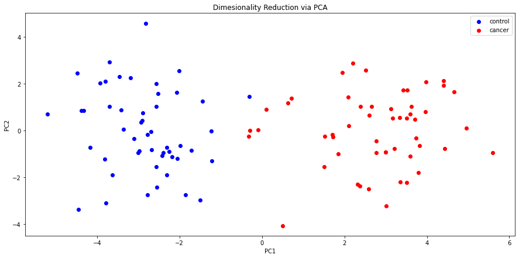

```python
# Proviamo a visualizzare i dati graficamente tramite una tencnica di riduzione della
# dimensionalità PCA (Analisi delle Componenti Principali)
# standardizzazione preliminare necessaria (scaling delle features a media=0 e deviazione stardard=1)
sc = StandardScaler()
X_std = sc.fit_transform(X)
# effettuo la pca su 3 componenti principali
# ovvero riproietto i dati su 3 dimensioni che riassumono la maggior parte della varianza dei dati
pca = PCA(n_components=3)
X_pca = pd.DataFrame(pca.fit_transform(X_std), columns=[f"PC{i}" for i in range(1,pca.n_components+1)])
X_pca["status"] = y
display(X_pca)

# visualizziamo le prime 2 Componenti PRincipali (PC)
plt.figure(figsize=(15,7))
for status,c in zip(["control", "cancer"], ["b", "r"]):
    plt.scatter(X_pca.query(f"status == '{status}'")["PC1"], X_pca.query(f"status == '{status}'")["PC2"], label=status, c=c)
plt.title("Dimesionality Reduction via PCA")
plt.xlabel("PC1")
plt.ylabel("PC2")
plt.legend()
plt.show()
```

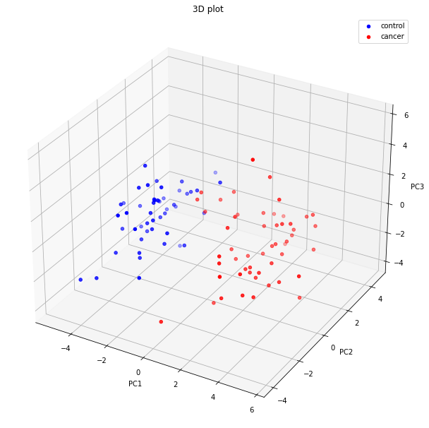

```python
# visualizziamo in 3d le prime 3 componenti principali
from mpl_toolkits.mplot3d import Axes3D
# creating figure
fig = plt.figure(figsize=(15,8))
ax = Axes3D(fig)

# creating the plot
ax.scatter(X_pca.query("status == 'control'")["PC1"],
           X_pca.query("status == 'control'")["PC2"],
           X_pca.query("status == 'control'")["PC3"], color='blue', label="control")

ax.scatter(X_pca.query("status == 'cancer'")["PC1"],
           X_pca.query("status == 'cancer'")["PC2"],
           X_pca.query("status == 'cancer'")["PC3"], color='red', label="cancer")

# setting title and labels
ax.set_title("3D plot")
ax.set_xlabel('PC1')
ax.set_ylabel('PC2')
ax.set_zlabel('PC3')

plt.legend()

# displaying the plot
plt.show()
```

### Codifica dati e Training del modello

```python
# ops! La variabile risposta deve essere codificata numericamente!
df_sel["status"].value_counts()
```

```
cancer     52
control    50
Name: status, dtype: int64
```

```python
# codifica variabile output y come varibile numerica (o 1 o 0)
y_enc = []
for sample in y:
    if sample == "control":
        y_enc.append(0)
    elif sample == "cancer":
        y_enc.append(1)
y_enc = np.array(y_enc)
y_enc
```

```
array([0, 1, 1, 0, 0, 0, 1, 0, 0, 0, 0, 0, 1, 1, 1, 0, 1, 0, 0, 0, 1, 1,
       0, 1, 0, 1, 0, 1, 0, 0, 1, 0, 1, 1, 0, 1, 0, 1, 1, 0, 0, 1, 0, 0,
       0, 1, 0, 0, 1, 0, 1, 0, 0, 0, 0, 0, 0, 0, 1, 0, 1, 0, 1, 1, 1, 1,
       1, 1, 0, 1, 1, 1, 1, 0, 1, 0, 1, 1, 1, 0, 1, 1, 1, 1, 0, 0, 0, 1,
       0, 0, 0, 1, 1, 1, 1, 1, 0, 1, 1, 0, 1, 1])
```

```python
# creamo ed addestriamo un modello MLP con Keras (tensorflow)
import tensorflow as tf
from tensorflow import keras
import tensorflow as tf
gpus = tf.config.experimental.list_physical_devices('GPU')
if gpus:
    try:
        for gpu in gpus:
            tf.config.experimental.set_memory_growth(gpu, True)
    except RuntimeError as e:
        print(e)

# istanziamo il modello e aggiungiamo gli starti della rete con l'API sequenziale della
# liberia Python Keras
model = keras.models.Sequential()
model.add(keras.layers.Dense(45, input_shape=(X.shape[1],)))
model.add(keras.layers.Dropout(0.005))
model.add(keras.layers.Dense(20, activation="relu"))
model.add(keras.layers.Dropout(0.005))
model.add(keras.layers.Dense(10, activation="relu"))
model.add(keras.layers.Dropout(0.001))
model.add(keras.layers.Dense(1, activation="sigmoid"))

# stampiamo la struttura del modello
print(model.summary())

# compiliamo il modello con i parametri necessari (ottimizzatore, funzione di costo per la backpropagation)
model.compile(
    optimizer=keras.optimizers.Adam(learning_rate=1e-4),
    loss=keras.losses.BinaryCrossentropy(),
    metrics=["accuracy"])

# addestriamo il modello sui dati codificati e standardizzati (numpy arrays X e y)
history = model.fit(x=X_std,
                    y=y_enc,
                    epochs=100,
                    verbose="auto",
                    callbacks=None,
                    validation_split=0.15,
                    shuffle=True)
```

[output not shown]

```
Model: "sequential"
_________________________________________________________________
 Layer (type)                Output Shape              Param #
=================================================================
 dense (Dense)               (None, 45)                2700

 dropout (Dropout)           (None, 45)                0

 dense_1 (Dense)             (None, 20)                920

 dropout_1 (Dropout)         (None, 20)                0

 dense_2 (Dense)             (None, 10)                210

 dropout_2 (Dropout)         (None, 10)                0

 dense_3 (Dense)             (None, 1)                 11

=================================================================
Total params: 3,841
Trainable params: 3,841
Non-trainable params: 0
_________________________________________________________________
None
```

```
2024-02-20 20:07:31.214545: I tensorflow/stream_executor/cuda/cuda_blas.cc:1774] TensorFloat-32 will be used for the matrix multiplication. This will only be logged once.
```

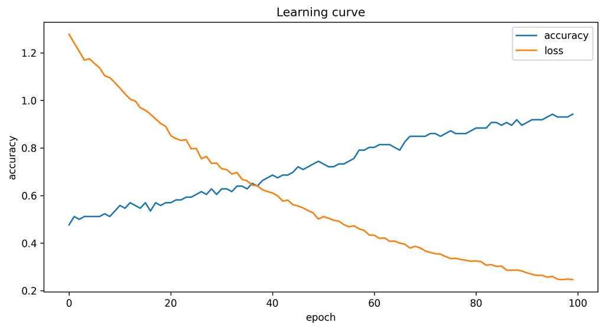

```python
plt.tight_layout()
plt.figure(figsize=(10,5), dpi=300)
for i in ["accuracy", "loss"]:
    plt.plot([_ for _ in range(len(history.history[i]))], history.history[i], label=i)
plt.title("Learning curve")
plt.xlabel("epoch")
plt.ylabel("accuracy")
plt.legend(loc="best")
plt.show()
```

```python
# campioniamo 5 campioni random ed facciamo predire alla rete la condizione del campione
# (N.B. sarebbe doveroso testare il modello su dati non usati per il training per verificarne le capacità di
# generalizzazione!!!! Per scopi didattici/divulgativi non lo faremo ed useremo un solo dataset)
df_sel_sample = df_sel.head(n=5)
df_sel_sample
```

|  | G2 | G11 | G332 | G364 | G579 | G610 | G694 | G698 | G702 | G721 | ... | G4316 | G4331 | G4396 | G4492 | G4518 | G4546 | G4549 | G4552 | G4981 | status |
| --- | --- | --- | --- | --- | --- | --- | --- | --- | --- | --- | --- | --- | --- | --- | --- | --- | --- | --- | --- | --- | --- |
| 30 | -0.823964 | 0.251442 | -0.823964 | 0.138768 | -0.823964 | -0.915303 | 0.796286 | -0.818667 | 0.202543 | -0.826735 | ... | 1.147321 | 0.721808 | 0.370868 | 0.168583 | -1.004718 | 0.852313 | 0.435736 | -0.850534 | -0.095333 | control |
| 67 | -0.369698 | 0.106081 | 0.011380 | 0.577476 | 0.560266 | 0.935378 | -0.873283 | -0.805812 | -0.829226 | 1.214019 | ... | -1.154922 | -1.156123 | -0.998680 | -0.370265 | -0.504671 | -0.805882 | -1.207726 | -0.303186 | 1.716053 | cancer |
| 62 | 3.172428 | -1.151800 | -0.941654 | 0.090186 | -0.819432 | -1.313248 | -0.885040 | -0.817794 | -0.518289 | -0.849807 | ... | -1.165739 | -1.166937 | -1.165739 | -0.774454 | 0.439612 | -0.817864 | -1.218367 | 2.415100 | 0.908331 | cancer |
| 47 | -0.843552 | -0.931968 | -0.843552 | 0.576515 | -0.843552 | -0.934813 | 0.559825 | -0.814364 | -0.837660 | -0.593221 | ... | 0.879616 | 1.214076 | 1.360127 | 0.697013 | -1.024150 | -0.194812 | -1.214237 | -0.823205 | 0.199189 | control |
| 42 | -0.836515 | -0.924519 | -0.836515 | 1.497905 | 0.032571 | -0.122194 | -0.874279 | -0.807463 | -0.830650 | -0.839271 | ... | 0.651291 | 0.547851 | 0.404417 | 1.496220 | 1.202796 | 1.345477 | -1.205471 | -0.862938 | 0.415909 | control |

5 rows × 60 columns

```python
# predizioni sui 5 campioni
for campione in range(df_sel_sample.shape[0]):
    print(f"\n\nPredizione su campione con indice:", str(campione))
    indice_campione = campione # 0-based
    display(df_sel.iloc[indice_campione,:].to_frame().T)
    print("Condizione campione:", df_sel.iloc[indice_campione,:]["status"])
    # predizione
    print(f"Predizione campione {indice_campione}:", model.predict(X_std[indice_campione,:].reshape(-1, X_std.shape[1]))[0][0]*100, "% (Probabilità Profilo Malatia).")
```

```
Predizione su campione con indice: 0
```

|  | G2 | G11 | G332 | G364 | G579 | G610 | G694 | G698 | G702 | G721 | ... | G4316 | G4331 | G4396 | G4492 | G4518 | G4546 | G4549 | G4552 | G4981 | status |
| --- | --- | --- | --- | --- | --- | --- | --- | --- | --- | --- | --- | --- | --- | --- | --- | --- | --- | --- | --- | --- | --- |
| 30 | -0.823964 | 0.251442 | -0.823964 | 0.138768 | -0.823964 | -0.915303 | 0.796286 | -0.818667 | 0.202543 | -0.826735 | ... | 1.147321 | 0.721808 | 0.370868 | 0.168583 | -1.004718 | 0.852313 | 0.435736 | -0.850534 | -0.095333 | control |

1 rows × 60 columns

```
Condizione campione: control
Predizione campione 0: 11.079152673482895 % (Probabilità Profilo Malatia).


Predizione su campione con indice: 1
```

|  | G2 | G11 | G332 | G364 | G579 | G610 | G694 | G698 | G702 | G721 | ... | G4316 | G4331 | G4396 | G4492 | G4518 | G4546 | G4549 | G4552 | G4981 | status |
| --- | --- | --- | --- | --- | --- | --- | --- | --- | --- | --- | --- | --- | --- | --- | --- | --- | --- | --- | --- | --- | --- |
| 67 | -0.369698 | 0.106081 | 0.01138 | 0.577476 | 0.560266 | 0.935378 | -0.873283 | -0.805812 | -0.829226 | 1.214019 | ... | -1.154922 | -1.156123 | -0.99868 | -0.370265 | -0.504671 | -0.805882 | -1.207726 | -0.303186 | 1.716053 | cancer |

1 rows × 60 columns

```
Condizione campione: cancer
Predizione campione 1: 72.71794080734253 % (Probabilità Profilo Malatia).


Predizione su campione con indice: 2
```

|  | G2 | G11 | G332 | G364 | G579 | G610 | G694 | G698 | G702 | G721 | ... | G4316 | G4331 | G4396 | G4492 | G4518 | G4546 | G4549 | G4552 | G4981 | status |
| --- | --- | --- | --- | --- | --- | --- | --- | --- | --- | --- | --- | --- | --- | --- | --- | --- | --- | --- | --- | --- | --- |
| 62 | 3.172428 | -1.1518 | -0.941654 | 0.090186 | -0.819432 | -1.313248 | -0.88504 | -0.817794 | -0.518289 | -0.849807 | ... | -1.165739 | -1.166937 | -1.165739 | -0.774454 | 0.439612 | -0.817864 | -1.218367 | 2.4151 | 0.908331 | cancer |

1 rows × 60 columns

```
Condizione campione: cancer
Predizione campione 2: 79.46028709411621 % (Probabilità Profilo Malatia).


Predizione su campione con indice: 3
```

|  | G2 | G11 | G332 | G364 | G579 | G610 | G694 | G698 | G702 | G721 | ... | G4316 | G4331 | G4396 | G4492 | G4518 | G4546 | G4549 | G4552 | G4981 | status |
| --- | --- | --- | --- | --- | --- | --- | --- | --- | --- | --- | --- | --- | --- | --- | --- | --- | --- | --- | --- | --- | --- |
| 47 | -0.843552 | -0.931968 | -0.843552 | 0.576515 | -0.843552 | -0.934813 | 0.559825 | -0.814364 | -0.83766 | -0.593221 | ... | 0.879616 | 1.214076 | 1.360127 | 0.697013 | -1.02415 | -0.194812 | -1.214237 | -0.823205 | 0.199189 | control |

1 rows × 60 columns

```
Condizione campione: control
Predizione campione 3: 0.5467816721647978 % (Probabilità Profilo Malatia).


Predizione su campione con indice: 4
```

|  | G2 | G11 | G332 | G364 | G579 | G610 | G694 | G698 | G702 | G721 | ... | G4316 | G4331 | G4396 | G4492 | G4518 | G4546 | G4549 | G4552 | G4981 | status |
| --- | --- | --- | --- | --- | --- | --- | --- | --- | --- | --- | --- | --- | --- | --- | --- | --- | --- | --- | --- | --- | --- |
| 42 | -0.836515 | -0.924519 | -0.836515 | 1.497905 | 0.032571 | -0.122194 | -0.874279 | -0.807463 | -0.83065 | -0.839271 | ... | 0.651291 | 0.547851 | 0.404417 | 1.49622 | 1.202796 | 1.345477 | -1.205471 | -0.862938 | 0.415909 | control |

1 rows × 60 columns

```
Condizione campione: control
Predizione campione 4: 1.5846313908696175 % (Probabilità Profilo Malatia).
```

```python
# predizione su tutti
y_hat_proba = pd.DataFrame(model.predict(X_std), columns = ["proba_cancer"])
y_hat_proba
```

|  | proba_cancer |
| --- | --- |
| 0 | 0.110787 |
| 1 | 0.727298 |
| 2 | 0.794612 |
| 3 | 0.005474 |
| 4 | 0.015841 |
| ... | ... |
| 97 | 0.912980 |
| 98 | 0.745672 |
| 99 | 0.167984 |
| 100 | 0.627013 |
| 101 | 0.014380 |

102 rows × 1 columns

```python
# aggiungo le probabilità predette al dataframe iniziale
df_sel["y_hat_proba"] = y_hat_proba["proba_cancer"].values * 100
df_sel
```

|  | G2 | G11 | G332 | G364 | G579 | G610 | G694 | G698 | G702 | G721 | ... | G4331 | G4396 | G4492 | G4518 | G4546 | G4549 | G4552 | G4981 | status | y_hat_proba |
| --- | --- | --- | --- | --- | --- | --- | --- | --- | --- | --- | --- | --- | --- | --- | --- | --- | --- | --- | --- | --- | --- |
| 30 | -0.823964 | 0.251442 | -0.823964 | 0.138768 | -0.823964 | -0.915303 | 0.796286 | -0.818667 | 0.202543 | -0.826735 | ... | 0.721808 | 0.370868 | 0.168583 | -1.004718 | 0.852313 | 0.435736 | -0.850534 | -0.095333 | control | 11.078669 |
| 67 | -0.369698 | 0.106081 | 0.011380 | 0.577476 | 0.560266 | 0.935378 | -0.873283 | -0.805812 | -0.829226 | 1.214019 | ... | -1.156123 | -0.998680 | -0.370265 | -0.504671 | -0.805882 | -1.207726 | -0.303186 | 1.716053 | cancer | 72.729774 |
| 62 | 3.172428 | -1.151800 | -0.941654 | 0.090186 | -0.819432 | -1.313248 | -0.885040 | -0.817794 | -0.518289 | -0.849807 | ... | -1.166937 | -1.165739 | -0.774454 | 0.439612 | -0.817864 | -1.218367 | 2.415100 | 0.908331 | cancer | 79.461235 |
| 47 | -0.843552 | -0.931968 | -0.843552 | 0.576515 | -0.843552 | -0.934813 | 0.559825 | -0.814364 | -0.837660 | -0.593221 | ... | 1.214076 | 1.360127 | 0.697013 | -1.024150 | -0.194812 | -1.214237 | -0.823205 | 0.199189 | control | 0.547416 |
| 42 | -0.836515 | -0.924519 | -0.836515 | 1.497905 | 0.032571 | -0.122194 | -0.874279 | -0.807463 | -0.830650 | -0.839271 | ... | 0.547851 | 0.404417 | 1.496220 | 1.202796 | 1.345477 | -1.205471 | -0.862938 | 0.415909 | control | 1.584138 |
| ... | ... | ... | ... | ... | ... | ... | ... | ... | ... | ... | ... | ... | ... | ... | ... | ... | ... | ... | ... | ... | ... |
| 60 | 0.149063 | 0.008004 | -0.826547 | 0.281539 | -0.744434 | -0.453682 | -0.864273 | -0.547006 | -0.820688 | 0.966206 | ... | -1.144088 | -0.123529 | -0.754504 | 1.526566 | -0.797593 | -0.253179 | -0.806315 | -1.033045 | cancer | 91.297989 |
| 71 | 3.890240 | -1.146564 | 1.255306 | -1.308767 | 0.655369 | 0.684815 | -0.878558 | -0.810998 | -0.834443 | 2.723672 | ... | -0.425151 | 1.491825 | 1.208888 | 1.267905 | -0.484161 | -0.475708 | 0.610215 | 1.416398 | cancer | 74.567169 |
| 14 | -0.832815 | -0.920530 | -0.832815 | 0.408398 | -0.832815 | -0.923351 | -0.950313 | -0.827566 | -0.649600 | -0.835562 | ... | 0.876069 | 0.404032 | 2.054222 | -0.838589 | 1.795931 | -0.715627 | -0.287856 | -1.149625 | control | 16.798407 |
| 92 | 0.563857 | 0.542990 | -1.163090 | -0.900649 | 0.806009 | -1.310149 | -0.883249 | -0.816208 | -0.588507 | -0.861749 | ... | -0.304625 | 0.430730 | -0.966360 | 2.052610 | -0.818461 | 0.096105 | -0.825038 | 0.607788 | cancer | 62.701267 |
| 51 | 0.248389 | -0.908733 | -0.821032 | 0.725486 | -0.821032 | -0.735914 | -0.858666 | -0.792080 | 0.804430 | 1.983584 | ... | -0.562993 | 1.190611 | 0.045635 | 0.366349 | -0.469960 | -1.188718 | 0.965079 | 0.079471 | cancer | 1.438017 |

102 rows × 61 columns

```python
# aggiungo le probabilità predette al dataframe PCA per visualizzare le predizioni
X_pca["y_hat_proba"] = y_hat_proba["proba_cancer"].values
X_pca
```

|  | PC1 | PC2 | PC3 | status | y_hat_proba |
| --- | --- | --- | --- | --- | --- |
| 0 | -2.934863 | 0.359831 | 0.614006 | control | 0.110787 |
| 1 | 2.992357 | -0.923589 | -1.065308 | cancer | 0.727298 |
| 2 | 3.733522 | -0.327145 | -0.646814 | cancer | 0.794612 |
| 3 | -2.903446 | 0.430020 | -0.545340 | control | 0.005474 |
| 4 | -2.975138 | -0.883952 | -1.061001 | control | 0.015841 |
| ... | ... | ... | ... | ... | ... |
| 97 | 3.619994 | 1.027024 | -0.306584 | cancer | 0.912980 |
| 98 | 4.438886 | -0.770030 | -1.283107 | cancer | 0.745672 |
| 99 | -4.456108 | -3.381453 | -2.358401 | control | 0.167984 |
| 100 | 3.166653 | 0.538153 | -0.392775 | cancer | 0.627013 |
| 101 | -0.325252 | -0.254966 | 2.073628 | cancer | 0.014380 |

102 rows × 5 columns

```python
y_hat = []
for i in y_hat_proba["proba_cancer"].values:
    if i>0.5:
        y_hat.append("cancer_pred")
    elif i<=0.5:
        y_hat.append("control_pred")
X_pca["y_hat"] = y_hat
X_pca
```

|  | PC1 | PC2 | PC3 | status | y_hat_proba | y_hat |
| --- | --- | --- | --- | --- | --- | --- |
| 0 | -2.934863 | 0.359831 | 0.614006 | control | 0.110787 | control_pred |
| 1 | 2.992357 | -0.923589 | -1.065308 | cancer | 0.727298 | cancer_pred |
| 2 | 3.733522 | -0.327145 | -0.646814 | cancer | 0.794612 | cancer_pred |
| 3 | -2.903446 | 0.430020 | -0.545340 | control | 0.005474 | control_pred |
| 4 | -2.975138 | -0.883952 | -1.061001 | control | 0.015841 | control_pred |
| ... | ... | ... | ... | ... | ... | ... |
| 97 | 3.619994 | 1.027024 | -0.306584 | cancer | 0.912980 | cancer_pred |
| 98 | 4.438886 | -0.770030 | -1.283107 | cancer | 0.745672 | cancer_pred |
| 99 | -4.456108 | -3.381453 | -2.358401 | control | 0.167984 | control_pred |
| 100 | 3.166653 | 0.538153 | -0.392775 | cancer | 0.627013 | cancer_pred |
| 101 | -0.325252 | -0.254966 | 2.073628 | cancer | 0.014380 | control_pred |

102 rows × 6 columns

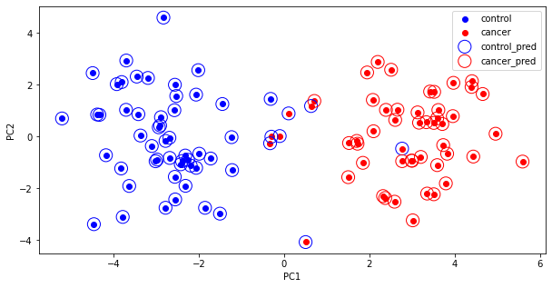

```python
plt.figure(figsize=(10,5))
for status,c in zip(["control", "cancer"], ["b", "r"]):
    plt.scatter(X_pca.query(f"status == '{status}'")["PC1"], X_pca.query(f"status == '{status}'")["PC2"], label=status, c=c)
for prediction,c in zip(["control_pred", "cancer_pred"], ["b", "r"]):
    plt.scatter(X_pca.query(f"y_hat == '{prediction}'")["PC1"], X_pca.query(f"y_hat == '{prediction}'")["PC2"], label=prediction, facecolors='none', edgecolors=c, s=200)
plt.legend()
plt.xlabel("PC1")
plt.ylabel("PC2")
plt.show()
```

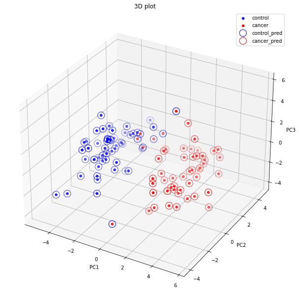

```python
# creating figure
fig = plt.figure(figsize=(15,8))
ax = Axes3D(fig)

# creating the plot
ax.scatter(X_pca.query("status == 'control'")["PC1"],
           X_pca.query("status == 'control'")["PC2"],
           X_pca.query("status == 'control'")["PC3"], color='blue', label="control")

ax.scatter(X_pca.query("status == 'cancer'")["PC1"],
           X_pca.query("status == 'cancer'")["PC2"],
           X_pca.query("status == 'cancer'")["PC3"], color='red', label="cancer")


ax.scatter(X_pca.query("y_hat == 'control_pred'")["PC1"],
           X_pca.query("y_hat == 'control_pred'")["PC2"],
           X_pca.query("y_hat == 'control_pred'")["PC3"], label="control_pred",
           facecolors='none', edgecolors="b", s=200)

ax.scatter(X_pca.query("y_hat == 'cancer_pred'")["PC1"],
           X_pca.query("y_hat == 'cancer_pred'")["PC2"],
           X_pca.query("y_hat == 'cancer_pred'")["PC3"], label="cancer_pred",
           facecolors='none', edgecolors="r", s=200)



# setting title and labels
ax.set_title("3D plot")
ax.set_xlabel('PC1')
ax.set_ylabel('PC2')
ax.set_zlabel('PC3')

plt.legend()

# displaying the plot
plt.show()
```

```python
%%HTML
<iframe width="560" height="315" src="https://www.youtube.com/embed/5_qrxVq1kvc?si=n5fysujTcgVCgJ7a&amp;start=1200" title="YouTube video player" frameborder="0" allow="accelerometer; autoplay; clipboard-write; encrypted-media; gyroscope; picture-in-picture; web-share" allowfullscreen></iframe>
```

[video not shown]

#### Playground Tensorflow:

Qui un link ad un interessante sito che simula in tempo reale il training e la validazione di una piccola rete neurale artificiale: playground.tensorflow.org .

### Github repository

Al seguente link sul mio repository potete trovare il materiale qui presentato (solo per scopi didattici/divulgativi):

[Repository GitHub](https://github.com/F0nz0/Log_a_Ritmi_2024)